# R Markdown

R Markdown is a platform developed by RStudio for creating dynamic documents. Using the R Markdown syntax, you can create HTML, PDF, and Word documents. You can also make slide presentations. See RStudio’s site for full documentation: [rmarkdown.rstudio.com](http://rmarkdown.rstudio.com/).

This tutorial covers the following topics:

- Getting started
- Basic syntax
- Choosing an output

## Getting started

Starting an R Markdown document is very easy. Click on the document icon in RStudio in the upper left hand corner.

[figure not shown]

Choose R Markdown.

[figure not shown]

You can then enter information about the title, the author, and the output format.

[figure not shown]

Once you click OK, there will be a new document in the top left panel of RStudio with some pre-populated information.

[figure not shown]

The information at the very top between the triple dashes is called the header. That is information that determines how the document will be rendered. You can edit the title, author, and date directly in the header. However, if you change any of the formatting, or change other information, it might break the document.

To render this document in HTML, click on the “Knit HTML” button.

[figure not shown]

Provide a file name for the document and save it.

[figure not shown]

RStudio will knit everything together and render the HTML in a window.

[figure not shown]

## Basic syntax

Markdown is a simple way to add formatting, like headers and bulleted lists, to to text. It’s an alternative to a mark-up language such as HTML. R Markdown is a version of markdown that allows you to integrate R code and output with text.

Below is some basic syntax for formatting a document.

#### Emphasis

```
*italic*  **bold**

_italic_  __bold__
```

#### Headers

```
# Header 1

## Header 2

### Header 3
```

#### Lists

```
- Item 1
- Item 2
    + Item 2a
    + Item 2b

1. Item 1
2. Item 2
    + Item 2a
    + Item 2b
```

#### R code and output

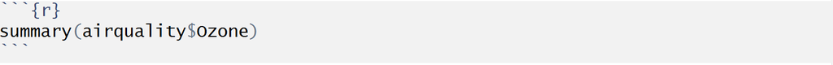

## Choosing an output

R Markdown can be rendered as an HTML page in a web browser. You can also choose Word or PDF as an output.

[figure not shown]

To compile a PDF document, you must first install Tex on your system. Go to the MikTex website to download and install the necessary software: [miktek.org/download](http://miktex.org/download).

You can also make presentation slides using R Markdown. Select the Presentation option when opening a new R Markdown document.

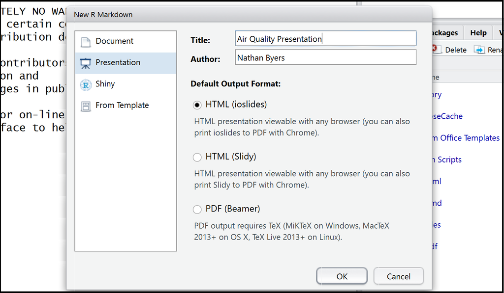

A pre-populated R Markdown document will be created.

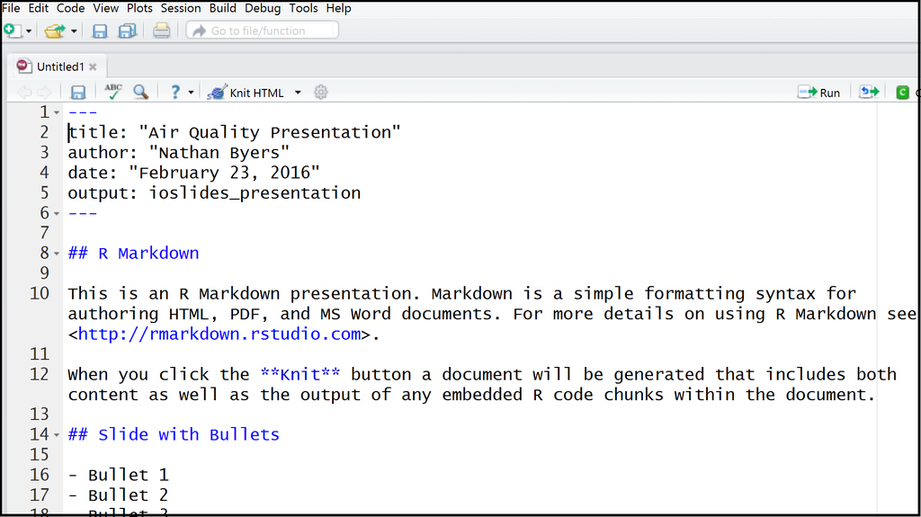

Save the file and click “Knit HTML” to see the slides.

[figure not shown]

## Further reading

- You can download the RStudio cheatsheet [here](https://www.rstudio.com/wp-content/uploads/2015/02/rmarkdown-cheatsheet.pdf).
- Download the longer reference guide [here](http://www.rstudio.com/wp-content/uploads/2015/03/rmarkdown-reference.pdf).
- R Markdown can be [integrated with Shiny](http://rmarkdown.rstudio.com/authoring_shiny.html) to make interactive documents.